#### The goal of this project is to predict the price of cars based on a dataset which contains about 130000 car offers for sale

#### there is data at year column which has the value of less than 1366 which makes us trouble in the future so I replaced it with 1365

#### I have merged two columns description and title into one column in description because there will be some preprocessing in future

```python
import pandas as pd
import numpy as  np
from __future__ import unicode_literals
from hazm import *
data = pd.read_csv("vehicles.csv")
del data['created_at']
data['description'] += " " + data['title']
del data['title']
data['year'].replace("<1366", 1365, inplace=True)
data
```

|  | brand | category | description | image_count | mileage | price | year |
| --- | --- | --- | --- | --- | --- | --- | --- |
| 0 | NaN | heavy | سریال 43j$NUMبدون شکستگی سه حلقه لاستیک نو یک ... | 4 | NaN | -1 | NaN |
| 1 | سایر | light | دوگانه ال پی جی بیمه با تخفیف دارد \nتودوزی نو... | 3 | 180000.0 | -1 | 1366 |
| 2 | پژو ۴۰۵::Peugeot 405 | light | پژو 2000فنی تازه تعمیر بدنه بدون خطو خش تخیف ب... | 0 | 290000.0 | 8500000 | 1381 |
| 3 | نیسان::Nissan | light | سلام.\nماشین کاملا سالم همه چی فابریک متور زد ... | 3 | 175000.0 | 19500000 | 1372 |
| 4 | سمند::Samand | light | سمند ال ایکس بدون رنگ تمامی سرویس ها انجام شده... | 4 | 80000.0 | 23900000 | 1391 |
| ... | ... | ... | ... | ... | ... | ... | ... |
| 130438 | NaN | heavy | بادسان فوق بیرنگ سفید رنگ بیمه تابرج 3.96 تخفی... | 2 | NaN | 48000000 | NaN |
| 130439 | NaN | heavy | باسلام .تراکتورازصفری دست خودم بوده.سالم.ودارا... | 4 | NaN | -1 | NaN |
| 130440 | سمند::Samand | light | ماشینم تصادفیه با خریدار توافق میکنم سر قیمتش ... | 3 | 20000.0 | -1 | 1392 |
| 130441 | پراید صندوق‌دار::Pride | light | سند۲ برگ،بیمه تا برج$NUMتخفیفات بیمه 15 سال،مع... | 4 | 123000.0 | 6900000 | 1379 |
| 130442 | پراید صندوق‌دار::Pride | light | پراید دوگانه کارخانه میباشد و کم کارکرد.روکش .... | 3 | 43000.0 | 17400000 | 1393 |

130443 rows × 7 columns

#### The data in description column should be preprocessed so the most relevant words to price could be predicted

#### I have done the preprocessing using HAZM library which is a special library for persian language

#### after removing the stop words and stemming and lemmatizing them, new set of words will be available

```python
from __future__ import unicode_literals
from hazm import *
stopword_dict = {sw:0 for sw in stopwords_list()}
stemmer = Stemmer()
lemmatizer = Lemmatizer()
document = []
i=0
t = data[data['price']!= -1]
for desc in t['description']:
    if i == 30000:
        break
    sentence = ""
    tokenized_sentence = word_tokenize(desc)
    for word in tokenized_sentence:
        if word in  [':','؟','.',',','«','»','(',')','،','[',']','{','}','-','','؛', '\r', '\n']:
            continue
        if word in stopword_dict:
            continue
        w = stemmer.stem(word)
        lemmitized_word = lemmatizer.lemmatize(w)
        sentence += lemmitized_word + " "
    document.append(sentence)
    i+=1
```

# 3

##### Finding the top 10 most recurrent words

##### With count vectorizing method, we can find out that whether a word is in a sentence or not and calculate the total number of repeats a word has in out dataset

##### By knowing this information, we can find the most recurrent words in our dataset and have a sence of which words have the most effects on our price prediction

```python
from sklearn.feature_extraction.text import CountVectorizer
import collections
import itertools

vectorizer = CountVectorizer()

cv_fit = vectorizer.fit_transform(document)

inv_map = {v: k for k, v in vectorizer.vocabulary_.items()}

count_vocab = cv_fit.toarray().sum(axis=0)

indexes = {}
for i in range(len(count_vocab)):
    indexes[count_vocab[i]] = i

tmp = collections.OrderedDict(sorted(indexes.items(), reverse = True))

tmp = dict(itertools.islice(tmp.items(), 10))

most_recurrent_words = []
for count in tmp:
    if tmp[count] in inv_map:
        most_recurrent_words.append(inv_map[tmp[count]])

most_recurrent_words.append('تمیز')
most_recurrent_words.pop(most_recurrent_words.index('لاستیک'))
most_recurrent_words
```

```
['سال', 'بیمه', 'رنگ', 'مدل', 'تخفیف', 'پراید', 'فن', 'نو', 'پژو', 'تمیز']
```

```python
for word in most_recurrent_words:
    repeats = []
    for row in data['description']:
        repeats.append(row.count(word))
    data[word] = repeats
del data['description']
data
```

|  | brand | category | image_count | mileage | price | year | سال | بیمه | رنگ | مدل | تخفیف | پراید | فن | نو | پژو | تمیز |
| --- | --- | --- | --- | --- | --- | --- | --- | --- | --- | --- | --- | --- | --- | --- | --- | --- |
| 0 | NaN | heavy | 4 | NaN | -1 | NaN | 1 | 0 | 0 | 0 | 0 | 0 | 0 | 1 | 0 | 0 |
| 1 | سایر | light | 3 | 180000.0 | -1 | 1366 | 0 | 1 | 0 | 0 | 1 | 1 | 0 | 1 | 0 | 0 |
| 2 | پژو ۴۰۵::Peugeot 405 | light | 0 | 290000.0 | 8500000 | 1381 | 2 | 2 | 0 | 1 | 0 | 0 | 1 | 0 | 2 | 0 |
| 3 | نیسان::Nissan | light | 3 | 175000.0 | 19500000 | 1372 | 1 | 0 | 0 | 0 | 0 | 0 | 0 | 1 | 0 | 0 |
| 4 | سمند::Samand | light | 4 | 80000.0 | 23900000 | 1391 | 0 | 0 | 1 | 0 | 0 | 0 | 0 | 0 | 0 | 0 |
| ... | ... | ... | ... | ... | ... | ... | ... | ... | ... | ... | ... | ... | ... | ... | ... | ... |
| 130438 | NaN | heavy | 2 | NaN | 48000000 | NaN | 1 | 1 | 2 | 1 | 1 | 0 | 0 | 0 | 0 | 0 |
| 130439 | NaN | heavy | 4 | NaN | -1 | NaN | 4 | 0 | 0 | 1 | 0 | 0 | 0 | 0 | 0 | 1 |
| 130440 | سمند::Samand | light | 3 | 20000.0 | -1 | 1392 | 0 | 0 | 0 | 1 | 0 | 0 | 0 | 0 | 0 | 0 |
| 130441 | پراید صندوق‌دار::Pride | light | 4 | 123000.0 | 6900000 | 1379 | 5 | 2 | 1 | 0 | 1 | 1 | 2 | 0 | 0 | 0 |
| 130442 | پراید صندوق‌دار::Pride | light | 3 | 43000.0 | 17400000 | 1393 | 1 | 1 | 0 | 1 | 0 | 2 | 0 | 0 | 0 | 0 |

130443 rows × 16 columns

##### Finding out which columns have Nan values:

```python
data.isna().sum()
```

```
brand          9992
category          0
image_count       0
mileage        9992
price             0
year           9992
سال               0
بیمه              0
رنگ               0
مدل               0
تخفیف             0
پراید             0
فن                0
نو                0
پژو               0
تمیز              0
dtype: int64
```

##### Nan values exist in only three columns(brand, mileage and year).So the Nan values will be removed and a new data frame with feature and price is created(We will need this dataframes in the future)

```python
brand_df = data.copy()[['brand','price']]
category_df = data.copy()[['category','price']]
brand_df.dropna(subset=['brand'],inplace=True)
mileage_df = data.copy()[['mileage','price']]
mileage_df.dropna(subset=['mileage'],inplace=True)
year_df = data.copy()[['year','price']]
year_df.dropna(subset=['year'],inplace=True)
```

##### In columns category and brand, the data type is a string of words and is categorial, so we label them with numbers instead

```python
category_df["category"] = category_df["category"].astype('category')
category_df["category"] = category_df["category"].cat.codes
brand_df["brand"] = brand_df["brand"].astype('category')
brand_df["brand"] = brand_df["brand"].cat.codes

data["category"] = data["category"].astype('category')
data["category"] = data["category"].cat.codes
data["brand"] = data["brand"].astype('category')
data["brand"] = data["brand"].cat.codes
```

# Fill Nan values:

# 4

### Ways to Handle Missing Values

#### There are too many ways to fill the values which are Nan here are two of them and I have chosen the second one:

##### 1.Deleting Rows with missing values

##### 2.Prediction of missing values using probability

##### The prediction of missing values is done using the data which is not Nan. for each of types a feature can have, a probability is calculated and by generarting a random number, a type of that feature will be chosen

# labeling categorial features:

# 2

#### There are two ways to encode the data:

### 1.Label encoder

### 2.OneHot encoder

#### I have chose to use the second method for brand feature because label encoding introduces a new problem.

#### The problem here is since there are different numbers in the same column, the model will misunderstand the data to be in some kind of order

#### The model may derive a correlation like as the brand number increases the population increases but this clearly may not be the scenario in some other data or the prediction set. To overcome this problem, we use One Hot Encoder.

```python
import random

def create_keys_ranges(df):
    counter = {}
    probs = {}
    keys_ranges = {}
    for row in df.iloc[:, 0]:
        if row in counter:
            counter[row] += 1
        else:
            counter[row] = 1

    for count in counter:
        probs[count] = counter[count]/len(df)

    prev_prob = 0
    for key in probs:
        keys_ranges[key] = [prev_prob, prev_prob + probs[key]]
        prev_prob += probs[key]

    return keys_ranges

brand_keys_ranges = create_keys_ranges(brand_df)
year_keys_ranges = create_keys_ranges(year_df)
mileage_keys_ranges = create_keys_ranges(mileage_df)

def fill_nan_randomly(keys_ranges):
    rand_num = random.random()
    for key in keys_ranges:
        if keys_ranges[key][0] < rand_num  and rand_num < keys_ranges[key][1]:
            return key

def fill_nan(col_name, col_keys_ranges):
    for row in range(len(data[col_name])):
        if data.at[row, col_name] == -1 or pd.isna(data.at[row, col_name]):
            num_to_replace = fill_nan_randomly(col_keys_ranges)
            data.at[row, col_name] = num_to_replace


fill_nan('brand', brand_keys_ranges)
fill_nan('mileage', mileage_keys_ranges)
fill_nan('year', year_keys_ranges)


y = pd.get_dummies(data.brand, prefix="brand")

for col in y.columns:
    data[col] = y[col]

del data["brand"]

test_data = data[data['price'] == -1]
train_data = data[data['price'] != -1]
train_data
```

|  | category | image_count | mileage | price | year | سال | بیمه | رنگ | مدل | تخفیف | ... | brand_16 | brand_17 | brand_18 | brand_19 | brand_20 | brand_21 | brand_22 | brand_23 | brand_24 | brand_25 |
| --- | --- | --- | --- | --- | --- | --- | --- | --- | --- | --- | --- | --- | --- | --- | --- | --- | --- | --- | --- | --- | --- |
| 2 | 1 | 0 | 290000.0 | 8500000 | 1381 | 2 | 2 | 0 | 1 | 0 | ... | 0 | 0 | 0 | 0 | 0 | 0 | 0 | 1 | 0 | 0 |
| 3 | 1 | 3 | 175000.0 | 19500000 | 1372 | 1 | 0 | 0 | 0 | 0 | ... | 0 | 0 | 0 | 0 | 0 | 0 | 0 | 0 | 0 | 0 |
| 4 | 1 | 4 | 80000.0 | 23900000 | 1391 | 0 | 0 | 1 | 0 | 0 | ... | 0 | 0 | 0 | 0 | 0 | 0 | 0 | 0 | 0 | 0 |
| 5 | 1 | 3 | 125000.0 | 8500000 | 1384 | 3 | 1 | 1 | 1 | 1 | ... | 0 | 0 | 0 | 0 | 0 | 0 | 0 | 1 | 0 | 0 |
| 6 | 1 | 2 | 11000.0 | 18500000 | 1393 | 1 | 1 | 1 | 1 | 1 | ... | 0 | 0 | 0 | 0 | 0 | 0 | 0 | 0 | 0 | 0 |
| ... | ... | ... | ... | ... | ... | ... | ... | ... | ... | ... | ... | ... | ... | ... | ... | ... | ... | ... | ... | ... | ... |
| 130435 | 1 | 2 | 173000.0 | 30000000 | 1390 | 1 | 0 | 1 | 0 | 0 | ... | 0 | 0 | 0 | 0 | 0 | 0 | 0 | 0 | 0 | 0 |
| 130436 | 1 | 3 | 140000.0 | 11000000 | 1384 | 1 | 1 | 2 | 2 | 0 | ... | 0 | 1 | 0 | 0 | 0 | 0 | 0 | 0 | 0 | 0 |
| 130438 | 0 | 2 | 46000.0 | 48000000 | 1394 | 1 | 1 | 2 | 1 | 1 | ... | 0 | 1 | 0 | 0 | 0 | 0 | 0 | 0 | 0 | 0 |
| 130441 | 1 | 4 | 123000.0 | 6900000 | 1379 | 5 | 2 | 1 | 0 | 1 | ... | 0 | 1 | 0 | 0 | 0 | 0 | 0 | 0 | 0 | 0 |
| 130442 | 1 | 3 | 43000.0 | 17400000 | 1393 | 1 | 1 | 0 | 1 | 0 | ... | 0 | 1 | 0 | 0 | 0 | 0 | 0 | 0 | 0 | 0 |

110054 rows × 41 columns

# Information Gain

```python
import math

price_dict = {}
for price in train_data['price']:
    if price in price_dict:
        price_dict[price] += 1
    else:
        price_dict[price] = 1

root_types_num = len(price_dict)


def find_I(df):
    price_dict = {}
    for price in df['price']:
        if price in price_dict:
            price_dict[price] += 1
        else:
            price_dict[price] = 1

    length = len(df)
    ans = 0
    for i in price_dict:
        p = price_dict[i]/length
        ans += -p * math.log(p,root_types_num)
    return ans


root_entropy = find_I(train_data)

def find_info_gain(df, feature):
    df_dict = {}
    for row in df[feature]:
        if row in df_dict:
            df_dict[row] += 1
        else:
            df_dict[row] = 1
    df_length = len(df)
    final_ans = 0
    for i in df_dict:
        type_probability = df_dict[i]/df_length
        temp_df = df[df[feature] == i]
        ans = find_I(temp_df)
        final_ans += type_probability * ans

    return root_entropy - final_ans

info_gains = []
info_gains_cols = []
for col in train_data.columns:
    if col != 'price' and col[:5] != "brand":
        ig = find_info_gain(train_data, col)
        info_gains.append(ig)
        info_gains_cols.append(col)
        print(col,"Information Gain: ", ig)
```

```
category Information Gain:  0.010786978834546046
image_count Information Gain:  0.005919775239621394
mileage Information Gain:  0.13791952349480896
year Information Gain:  0.07861320821061946
سال Information Gain:  0.00953299593518131
بیمه Information Gain:  0.009042812934907496
رنگ Information Gain:  0.006055178407838313
مدل Information Gain:  0.003507035398436442
تخفیف Information Gain:  0.009409804932179466
پراید Information Gain:  0.024689609828763448
فن Information Gain:  0.004296322247058337
نو Information Gain:  0.0037184308382253173
پژو Information Gain:  0.0074623280569611206
تمیز Information Gain:  0.002122170686144509
```

# 1

#### after calculating the information gain as we see, the mileage gives us the most information compared to other features.it means that if we seperate the data by every car's mileage amount, we can achieve the best price prediction. And for example in algorithms like decision tree algorithm, we must consider the root value to be mileage

```
max information gain is 0.13791952349480896 which is for feature  mileage
```

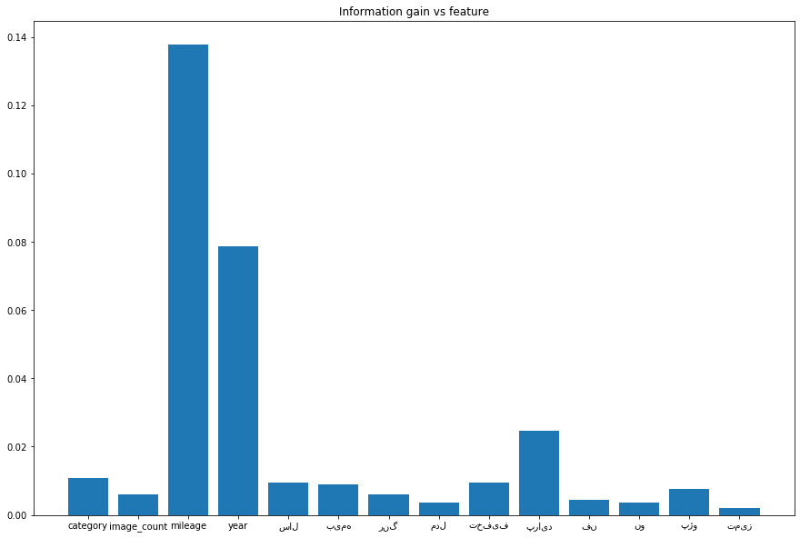

```python
import matplotlib.pyplot as plt
plt.figure(figsize =(15, 10))
plt.bar(info_gains_cols, info_gains)
plt.title('Information gain vs feature')
max_ig = max(info_gains)
idx = info_gains.index(max_ig)
print("max information gain is", max_ig, "which is for feature ",info_gains_cols[idx])
```

# RMSE and MSE

```python
from sklearn import metrics

def rmse(ans, predicted):
    sum = 0
    n = len(predicted)
    count= 0
    for y in ans:
        a = y - predicted[count]
        sum += (a ** 2) / n
        count += 1
    return math.sqrt(sum)

def mse(ans, predicted):
    sum = 0
    n = len(predicted)
    count= 0
    for y in ans:
        a = y - predicted[count]
        sum += a ** 2
        count += 1
    return sum / n
```

```python
from sklearn.preprocessing import StandardScaler
from sklearn.model_selection import train_test_split
```

# KNN

```python
from sklearn.neighbors import KNeighborsClassifier

scaler = StandardScaler()

scaler.fit(train_data.drop('price', axis = 1))
scaled_features = scaler.transform(train_data.drop('price', axis = 1))

df_feat = pd.DataFrame(scaled_features, columns = train_data.columns[:-1])
df_feat.head()
```

|  | category | image_count | mileage | price | year | سال | بیمه | رنگ | مدل | تخفیف | ... | brand_15 | brand_16 | brand_17 | brand_18 | brand_19 | brand_20 | brand_21 | brand_22 | brand_23 | brand_24 |
| --- | --- | --- | --- | --- | --- | --- | --- | --- | --- | --- | --- | --- | --- | --- | --- | --- | --- | --- | --- | --- | --- |
| 0 | 0.245481 | -1.283489 | 1.910656 | -1.196150 | 1.072485 | 1.868864 | -1.090658 | 0.775541 | -0.687858 | -0.56007 | ... | -0.190012 | -0.566193 | -0.230058 | -0.181585 | -0.280095 | -0.153394 | -0.302619 | 3.027183 | -0.199758 | -0.103211 |
| 1 | 0.245481 | 0.753492 | 0.736521 | -2.815171 | 0.059663 | -1.070099 | -1.090658 | -0.775316 | -0.687858 | -0.56007 | ... | -0.190012 | -0.566193 | -0.230058 | -0.181585 | -0.280095 | -0.153394 | -0.302619 | -0.330340 | -0.199758 | -0.103211 |
| 2 | 0.245481 | 1.432486 | -0.233418 | 0.602762 | -0.953159 | -1.070099 | 0.327732 | -0.775316 | -0.687858 | -0.56007 | ... | -0.190012 | -0.566193 | -0.230058 | -0.181585 | -0.280095 | -0.153394 | -0.302619 | -0.330340 | -0.199758 | -0.103211 |
| 3 | 0.245481 | 0.753492 | 0.226027 | -0.656477 | 2.085307 | 0.399383 | 0.327732 | 0.775541 | 1.139533 | -0.56007 | ... | -0.190012 | -0.566193 | -0.230058 | -0.181585 | -0.280095 | -0.153394 | -0.302619 | 3.027183 | -0.199758 | -0.103211 |
| 4 | 0.245481 | 0.074498 | -0.937899 | 0.962544 | 0.059663 | 0.399383 | 0.327732 | 0.775541 | 1.139533 | -0.56007 | ... | -0.190012 | -0.566193 | -0.230058 | -0.181585 | -0.280095 | -0.153394 | -0.302619 | -0.330340 | -0.199758 | -0.103211 |

5 rows × 40 columns

```python
  X_train, X_test, y_train, y_test = train_test_split(scaled_features, train_data['price'], test_size = 0.30)
```

```python
import seaborn as sns
import matplotlib.pyplot as plt

error_rate = []

for i in range(1, 32, 10):
    print(i)
    knn = KNeighborsClassifier(n_neighbors = i)
    knn.fit(X_train, y_train)
    pred_i = knn.predict(X_test)
    error_rate.append(np.mean(pred_i != y_test))
```

```
1
11
21
31
```

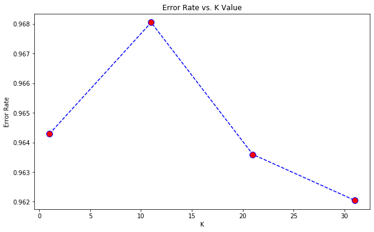

```python
plt.figure(figsize =(10, 6))
plt.plot(range(1, 32,10), error_rate, color ='blue',
                linestyle ='dashed', marker ='o',
         markerfacecolor ='red', markersize = 10)

plt.title('Error Rate vs. K Value')
plt.xlabel('K')
plt.ylabel('Error Rate')
```

```python
knn = KNeighborsClassifier(n_neighbors = 31)

knn.fit(X_train, y_train)
pred = knn.predict(X_test)

print('RMSE: ', rmse(y_test, pred))
print('MSE: ', metrics.mean_squared_error(y_test, pred))
```

```
RMSE:  23801751.88655298
MSE:  566523392869003.1
```

# Linear Regression (test_size = 20%) :

```python
from sklearn.linear_model import LinearRegression


y = train_data['price']
X = train_data.drop('price', axis=1)

X_train, X_test, y_train, y_test = train_test_split(X, y, test_size=0.2, random_state=0)

regressor = LinearRegression()
regressor.fit(X_train, y_train)
y_pred = regressor.predict(X_test)

print('RMSE: ', rmse(y_test, y_pred))
print('MSE: ', metrics.mean_squared_error(y_test, y_pred))
```

```
RMSE:  21370308.21117967
MSE:  456690073040812.4
```

# Linear Regression (test_size = 2%) :

```python
from sklearn.linear_model import LinearRegression


y = train_data['price']
X = train_data.drop('price', axis=1)

X_train, X_test, y_train, y_test = train_test_split(X, y, test_size=0.02, random_state=0)

regressor = LinearRegression()
regressor.fit(X_train, y_train)
y_pred = regressor.predict(X_test)

print('RMSE: ', rmse(y_test, y_pred))
print('MSE: ', metrics.mean_squared_error(y_test, y_pred))
```

```
RMSE:  21636580.21287708
MSE:  468141603308264.1
```

# Linear Regression (test_size = 60%) :

```python
from sklearn.linear_model import LinearRegression


y = train_data['price']
X = train_data.drop('price', axis=1)

X_train, X_test, y_train, y_test = train_test_split(X, y, test_size=0.6, random_state=0)

regressor = LinearRegression()
regressor.fit(X_train, y_train)
y_pred = regressor.predict(X_test)

print('RMSE: ', rmse(y_test, y_pred))
print('MSE: ', metrics.mean_squared_error(y_test, y_pred))
```

```
RMSE:  21404536.09785662
MSE:  458154165564445.3
```

# 5

### As we see, if we choose a small data set to train on, underfitting may occur and we we choose a big dataset for training, overfitting may happen

# Decision Tree

```python
from sklearn.tree import DecisionTreeClassifier

X = train_data.drop('price', axis=1)
y = train_data['price']

X_train, X_test, y_train, y_test = train_test_split(X, y, test_size=0.20)

rmses = []
mses = []
for i in range(10,30):
    classifier = DecisionTreeClassifier(max_depth = i)
    classifier.fit(X_train, y_train)
    pred_i = classifier.predict(X_test)
    rmses.append(rmse(y_test, pred_i))
    mses.append(metrics.mean_squared_error(y_test, pred_i))
```

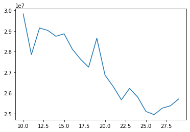

```python
plt.plot(range(10,30), rmses)
```

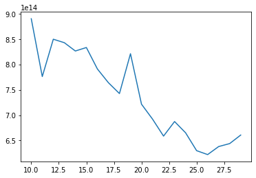

```python
plt.plot(range(10,30), mses)
```

# 6

```python
from sklearn.tree import DecisionTreeClassifier

X = train_data.drop('price', axis=1)
y = train_data['price']

X_train, X_test, y_train, y_test = train_test_split(X, y, test_size=0.20)

classifier = DecisionTreeClassifier(max_depth = 26)
classifier.fit(X_train, y_train)

y_pred = classifier.predict(X_test)

print('RMSE: ', rmse(y_test, y_pred))
print('MSE: ', metrics.mean_squared_error(y_test, y_pred))
```

```
RMSE:  25375893.638712827
MSE:  643935977963249.6
```

# Random Forest Regressor

```python
from sklearn.ensemble import RandomForestRegressor

y = train_data['price']
X = train_data.drop('price', axis=1)

X_train, X_test, y_train, y_test = train_test_split(X, y, test_size=0.2, random_state=0)

sc = StandardScaler()
X_train = sc.fit_transform(X_train)
X_test = sc.transform(X_test)

regressor = RandomForestRegressor(n_estimators=50, random_state=0)
regressor.fit(X_train, y_train)
y_pred = regressor.predict(X_test)

print('RMSE: ', rmse(y_test, y_pred))
print('MSE: ', metrics.mean_squared_error(y_test, y_pred))
```

```
RMSE:  18693416.393563032
MSE:  349443816463130.5
```

# 7

### What is bias?

#### Bias is the difference between the average prediction of our model and the correct value which we are trying to predict. Model with high bias pays very little attention to the training data and oversimplifies the model. It always leads to high error on training and test data.

### What is variance?

#### Variance is the variability of model prediction for a given data point or a value which tells us spread of our data. Model with high variance pays a lot of attention to training data and does not generalize on the data which it hasn’t seen before. As a result, such models perform very well on training data but has high error rates on test data.

#### An optimal balance of bias and variance would never overfit or underfit the model.

#### if we consider to minimize the bias, the desicion tree algorithm works much better but if we consider to maximize the variance, the random forest algorithm works much better because the random forest method limits the allowed variables to split on in each node

[figure not shown]